# Impact of Tracing on LTFU HIV Patients – Progress Update

David Chen & Max Murphy

11/14/2019

# Group Introduction

- David Chen
  - Masters of Biostatistics interested in approaches to optimal dynamic treatment and applications in mental health
- Max Murphy
  - PhD. Biostatistics working on malaria transmission dynamics jointly with Dr. Rasmus Nielsen at UCB and Dr. Bryan Greenhouse at UCSF

# Study Background

- A 2015-2017 study was conducted in Zambia to improve estimates of baseline mortality due to HIV
- A subset of individuals who were lost to follow up were randomized to receive extra care through follow up outreach by community health workers
- What are the impacts of this type of intervention
  - Returning people to care
  - Maintaining care over time.

# Target Population

Zambian, HIV positive adult patients on ART who are lost to follow-up ($\geq 90$ days late for their last appointment or $\geq 180$ days without clinic visit for patients with no future appointment scheduled at their last visit).

Patients satisfying the above criteria who have also already returned to care.

# Target Parameter

The treatment specific survival curve

$$\begin{align*}
\Psi(P_0) = \mathbb{E}_{P_0}[S_0(t_0 | A = d(w), W)] \\
S_0(t_0 | A, W) = \prod_{t \in [0, t_0]}(1 - \Lambda_0(dt | A, W))
\end{align*}$$

We’re interested in comparing the impact of tracing assignment on (1) time to return to care and (2) duration of retention in care.

# Progress - Data Processing

- Conducted data cleaning and imputation of missing values
- Compiled data set consisting of 30374 entries
  - 3207 individuals assigned to treatment
  - 27167 individuals assigned to control

# Treatment Group

|  | 0 (n=27167) | 1 (n=3207) | Overall (n=30374) |
| --- | --- | --- | --- |
| age |  |  |  |
| Mean (SD) | 38.2 (10.2) | 38.8 (10.5) | 38.3 (10.3) |
| Median [Min, Max] | 37.0 [15.1, 84.4] | 37.6 [18.1, 84.6] | 37.1 [15.1, 84.6] |
| province |  |  |  |
| Eastern | 3275 (12.1%) | 624 (19.5%) | 3899 (12.8%) |
| Southern | 2438 (9.0%) | 565 (17.6%) | 3003 (9.9%) |
| Lusaka | 17665 (65.0%) | 1409 (43.9%) | 19074 (62.8%) |
| Western | 3789 (13.9%) | 609 (19.0%) | 4398 (14.5%) |
| fac_type |  |  |  |
| hospital | 6992 (25.7%) | 844 (26.3%) | 7836 (25.8%) |
| rural | 2770 (10.2%) | 731 (22.8%) | 3501 (11.5%) |
| urban | 17405 (64.1%) | 1632 (50.9%) | 19037 (62.7%) |
| educ |  |  |  |
| 1-6 | 6063 (22.3%) | 783 (24.4%) | 6846 (22.5%) |
| 7-12 | 17735 (65.3%) | 1959 (61.1%) | 19694 (64.8%) |
| none | 2024 (7.5%) | 310 (9.7%) | 2334 (7.7%) |
| college/univ | 1345 (5.0%) | 155 (4.8%) | 1500 (4.9%) |
| enroll_HIV_stage |  |  |  |
| Mean (SD) | 1.94 (0.952) | 1.91 (0.941) | 1.94 (0.951) |
| Median [Min, Max] | 2.00 [1.00, 4.00] | 2.00 [1.00, 4.00] | 2.00 [1.00, 4.00] |
| hh_inc |  |  |  |
| 100-199K | 3311 (12.2%) | 469 (14.6%) | 3780 (12.4%) |
| <50K | 4433 (16.3%) | 615 (19.2%) | 5048 (16.6%) |
| 500K | 10033 (36.9%) | 933 (29.1%) | 10966 (36.1%) |
| 50-99K | 2102 (7.7%) | 318 (9.9%) | 2420 (8.0%) |
| 200-499K | 7288 (26.8%) | 872 (27.2%) | 8160 (26.9%) |
| factor(male) |  |  |  |
| 0 | 16483 (60.7%) | 1922 (59.9%) | 18405 (60.6%) |
| 1 | 10684 (39.3%) | 1285 (40.1%) | 11969 (39.4%) |

# Progress - Analysis

- Currently exploring techniques of estimating survival curves
  - Attempting to use `survtmle` and `MOSS`
  - Issues with `MOSS` on this data set, experiencing memory issues

# Lost To Follow Up

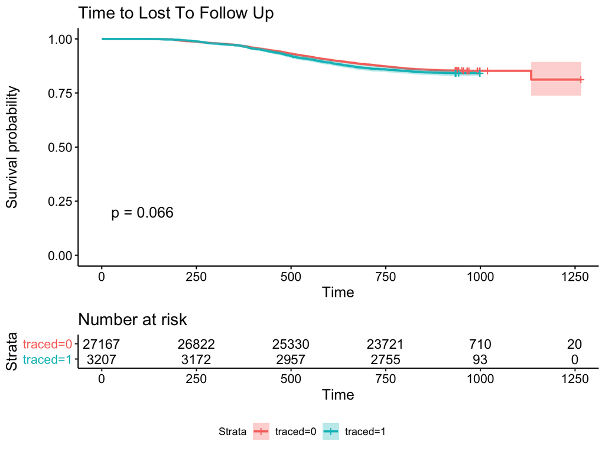

# Time to Return

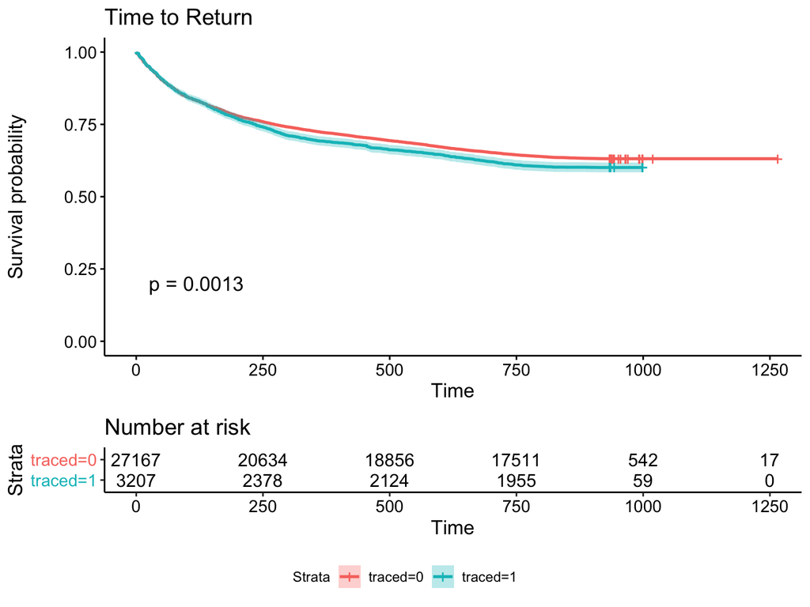